# Analysis on Adelaide CBD Air Quality Data

# Background

The Environment Protection Authority (EPA) monitors South Australian airsheds in order to assess the air quality and provide information that can be used to guide management decisions. This data set contains validated particle pollution data for the Adelaide CBD region. This site was commissioned in April 2014.

Set-up libraries:

```r
library("tidyverse")
library("lubridate", "dplyr", "forcats")
```

```r
# Writing the function "multmerge" to merge multiple datasets. It takes the path of the input files (mypath) and ouput file (output_file) as arguments.
multmerge <- function(mypath,output_file) {
  filenames = list.files(path = mypath, full.names = TRUE)
  DF <-  read.csv(filenames[1])
  for (f in filenames[-1]) DF <- rbind(DF, read.csv(f))
  write.csv(DF, output_file, row.names=FALSE, quote=FALSE)
}
multmerge(mypath = "./ADL07p", output_file = "particle.csv")
particle <- read.csv("particle.csv")
```

Let’s see what we got:

```r
str(particle)
```

```
'data.frame':   59304 obs. of  5 variables:
 $ Date.Time              : Factor w/ 59304 levels "10/01/2015 0:00",..: 2161 2162 2163 2164 2165 2166 2173 2180 2187 2194 ...
 $ PM10.BAM.ug.m3         : num  NA NA NA NA NA NA NA NA NA NA ...
 $ PM2.5.BAM.ug.m3        : num  NA NA NA NA NA NA NA NA NA NA ...
 $ Temperature.Deg.C      : num  NA NA NA NA NA NA NA NA NA NA ...
 $ Barometric.Pressure.atm: num  NA NA NA NA NA NA NA NA NA NA ...
```

Field labels: PM10 BAM ug/m3 – Particulate Matter 10 microns or less, PM2.5 BAM ug/m3 – Particulate Matter 2.5 microns or less, Temperature Deg C – Ambient Temperature, Barometric Pressure atm – Ambient Pressure. Data was collected as 10 minute averages. Information provided is PM10 and PM2.5 values expressed in micrograms per cubic metre (ug/m3), Ambient Temperature expressed in Degrees Celsius (Deg C) & Ambient Barometric Pressure expressed in Atmospheres (atm). Time is expressed as Time Ending Averages.

# Data Exploration

We should organize the dates to its proper format and rename the columns for easy access. We also separate a column for each the components of time like year, month, days of the week and hour of the day.

| date_time | pm10 | pm2.5 | temp | bar | year | month | wday | hour |
| --- | --- | --- | --- | --- | --- | --- | --- | --- |
| 2014-04-01 00:10:00 | NA | NA | NA | NA | 2014 | 4 | 3 | 0 |
| 2014-04-01 00:20:00 | NA | NA | NA | NA | 2014 | 4 | 3 | 0 |
| 2014-04-01 00:30:00 | NA | NA | NA | NA | 2014 | 4 | 3 | 0 |
| 2014-04-01 00:40:00 | NA | NA | NA | NA | 2014 | 4 | 3 | 0 |
| 2014-04-01 00:50:00 | NA | NA | NA | NA | 2014 | 4 | 3 | 0 |
| 2014-04-01 01:00:00 | NA | NA | NA | NA | 2014 | 4 | 3 | 1 |
| 2014-04-01 01:10:00 | NA | NA | NA | NA | 2014 | 4 | 3 | 1 |
| 2014-04-01 01:20:00 | NA | NA | NA | NA | 2014 | 4 | 3 | 1 |
| 2014-04-01 01:30:00 | NA | NA | NA | NA | 2014 | 4 | 3 | 1 |
| 2014-04-01 01:40:00 | NA | NA | NA | NA | 2014 | 4 | 3 | 1 |

[output cut: 990 more lines]

```r
summarise(particle, avg_pm10 = mean(pm10, na.rm =TRUE), avg_pm2.5 = mean(pm2.5, na.rm = TRUE))
```

| avg_pm10 | avg_pm2.5 |
| --- | --- |
| 15.2457 | 6.270915 |

Now, let’s see what hours have the highest particulate matter(PM). To simplify our analysis, we choose to focus first on PM10 variable.

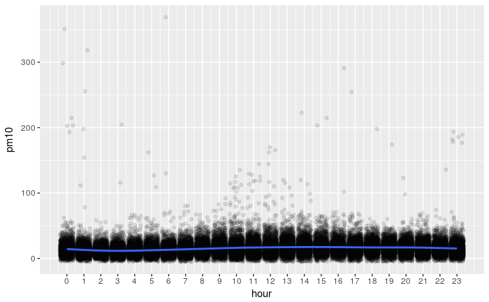

```r
ggplot(particle, mapping = aes(x=hour, y=pm10)) +
  geom_point(position = "jitter", na.rm = TRUE, alpha = 1/10)+
  geom_smooth(na.rm = TRUE)+
  scale_x_continuous(breaks = c(0:23))
```

This plot does not show clearly the fluctuation of PM per hour. Perhaps, if we cluster our data per month and take the averages of particular hour, we can see a pattern.

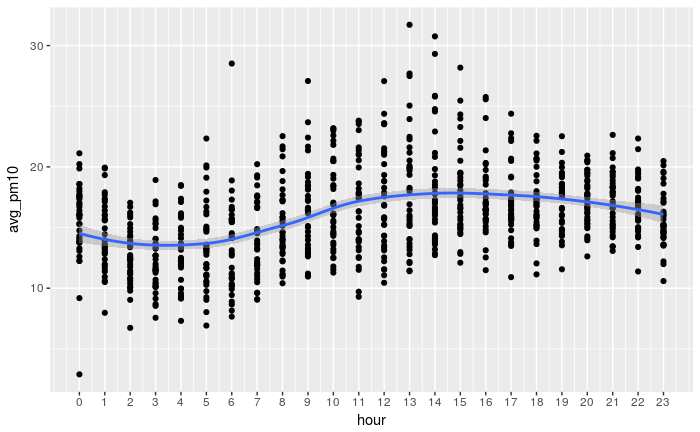

**The plot above suggests that there are most PM10 in the air on average during the day from 1pm to around 2pm then gradually lessens until when the air is cleanest at around 3am to 4am.**

Some months have pretty high average hourly rates so we can suspect that the season and time of the year has and effect on it. Let’s try color-coding the plot by month and see if there is a pattern.

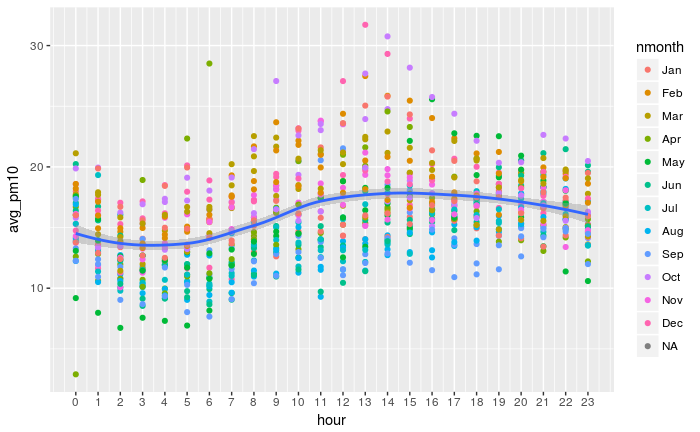

We can observe in the plot above that the months of November to January have higher PM rating than the other months. **We can theorise that there is a relationship of season being dry or wet on the air quality.** To prove this theory, we have to group our months by season:

```r
fct_reorder(particle$season, season_order)
```

```
Error: length(f) == length(x) is not TRUE
```

This time, we are now interested in translating our findings into numbers.

| avg_pm10 | avg_pm2.5 |
| --- | --- |
| 15.2457 | 6.270915 |

| season | avg_pm10_season | perc_delta_pm10 | avg_pm2.5_season | perc_delta_pm2.5 |
| --- | --- | --- | --- | --- |
| Autumn | 14.79231 | -0.02973900 | 5.747820 | -0.08341614 |
| Spring | 16.27132 | 0.06727279 | 6.633170 | 0.05776752 |
| Summer | 16.43557 | 0.07804630 | 6.793865 | 0.08339290 |
| Winter | 13.88339 | -0.08935676 | 6.046155 | -0.03584164 |

We also like to investigate how our data in Adelaide CBD compare to acceptable healthy measurements.